# Titanic - Machine Learning from Disaster

Filip Wilhelm Sjöstrand

2024-02-06

# Introduction

We are tasked with creating a prediction model on “what sorts of people were more likely to survive”? We shall create a logistic regression model with `Survived` as response variable. With this model, we will apply a test data set to see its predictions.

# Tidying

We observe large missing values for `Cabin`, thus being dropped. Other insignificant values dropped are `PassengerId` since it is only an index, `Name`/`Ticket` since it is difficult to categorize, and the very few NAs in `Embarked`.

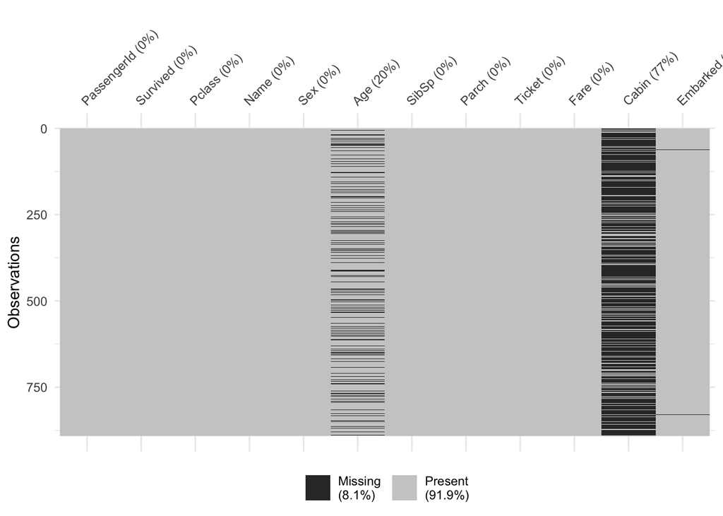

```r
# NA analysis ---------
train %>% visdat::vis_miss()
```

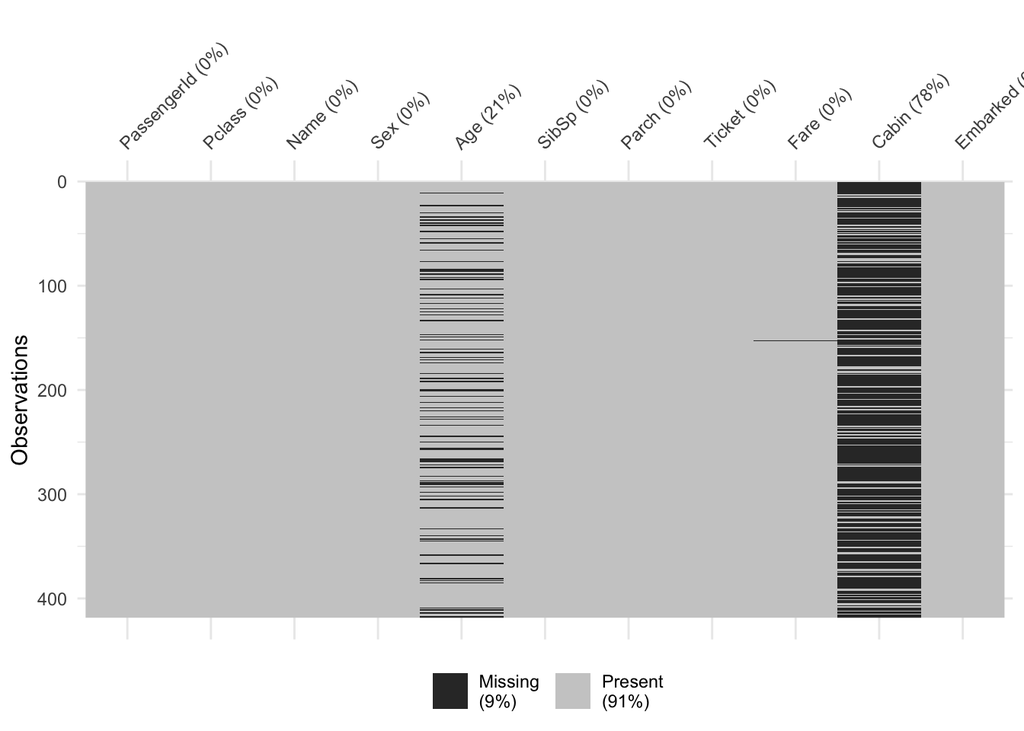

```r
test %>% visdat::vis_miss()
```

```r
train <- train %>%
    select(-PassengerId, -Cabin, -Name, -Ticket) %>%
    filter(!is.na(Embarked))

test <- test %>%
    select(-Cabin, -Name, -Ticket) %>%
    filter(!is.na(Embarked))
```

Given `Age`’s approximately normal distribution, I am going to assume no systematic missing NA and replace missing values with the average.

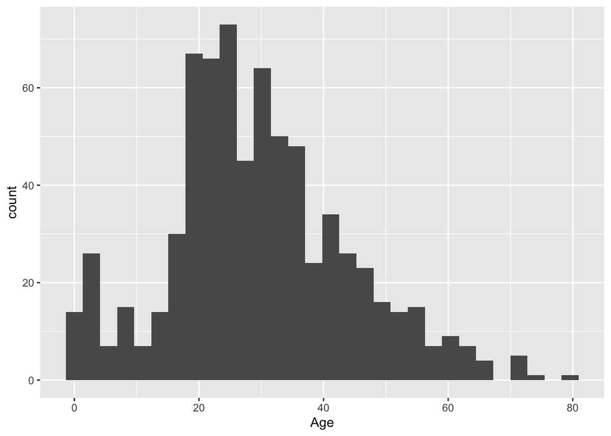

```r
train %>% ggplot() + geom_histogram(aes(Age))
```

```r
train <- train %>%
    mutate(Age = replace_na(Age, mean(train$Age,na.rm=T)))

test <- test %>%
    mutate(Age = replace_na(Age, mean(test$Age,na.rm=T)))
```

We need to ensure every data type is correct. We can observe that `Survived`, `Pclass`, `Sex`, and `Embarked` are not factors—hence transformed.

```r
sapply(train, is.factor)
```

```
## Survived   Pclass      Sex      Age    SibSp    Parch     Fare Embarked
##    FALSE    FALSE    FALSE    FALSE    FALSE    FALSE    FALSE    FALSE
```

```r
train <- train %>%
    mutate(across(c(Survived, Pclass, Sex, Embarked), as.factor))

test <- test %>%
    mutate(across(c(Pclass, Sex, Embarked), as.factor))
```

A last check on the summary values indicates nothing out of the ordinary.

```r
summary(train)
```

```
##  Survived Pclass      Sex           Age            SibSp
##  0:549    1:214   female:312   Min.   : 0.42   Min.   :0.0000
##  1:340    2:184   male  :577   1st Qu.:22.00   1st Qu.:0.0000
##           3:491                Median :29.64   Median :0.0000
##                                Mean   :29.64   Mean   :0.5242
##                                3rd Qu.:35.00   3rd Qu.:1.0000
##                                Max.   :80.00   Max.   :8.0000
##      Parch             Fare         Embarked
##  Min.   :0.0000   Min.   :  0.000   C:168
##  1st Qu.:0.0000   1st Qu.:  7.896   Q: 77
##  Median :0.0000   Median : 14.454   S:644
##  Mean   :0.3825   Mean   : 32.097
##  3rd Qu.:0.0000   3rd Qu.: 31.000
##  Max.   :6.0000   Max.   :512.329
```

# Model Fitting

From first including every predictor, we observed that `Parch`, `Fare`, and `Embarked` were insignificant.

```r
model <- glm(
    Survived ~ Pclass + Sex + SibSp + Age,
    family = binomial(link = 'logit'),
    data = train
    )

summary(model)
```

```
##
## Call:
## glm(formula = Survived ~ Pclass + Sex + SibSp + Age, family = binomial(link = "logit"),
##     data = train)
##
## Coefficients:
##              Estimate Std. Error z value Pr(>|z|)
## (Intercept)  4.021215   0.399832  10.057  < 2e-16 ***
## Pclass2     -1.182964   0.261934  -4.516 6.29e-06 ***
## Pclass3     -2.341409   0.242958  -9.637  < 2e-16 ***
## Sexmale     -2.732915   0.194371 -14.060  < 2e-16 ***
## SibSp       -0.356999   0.104090  -3.430 0.000604 ***
## Age         -0.040054   0.007813  -5.127 2.95e-07 ***
## ---
## Signif. codes:  0 '***' 0.001 '**' 0.01 '*' 0.05 '.' 0.1 ' ' 1
##
## (Dispersion parameter for binomial family taken to be 1)
##
##     Null deviance: 1182.82  on 888  degrees of freedom
## Residual deviance:  790.31  on 883  degrees of freedom
## AIC: 802.31
##
## Number of Fisher Scoring iterations: 5
```

## Diagnostics

Relatively high McFadden’s $R^2$

```r
pscl::pR2(model)["McFadden"]
```

```
## fitting null model for pseudo-r2
```

```
##  McFadden
## 0.3318441
```

No high VIF

```r
car::vif(model)
```

```
##            GVIF Df GVIF^(1/(2*Df))
## Pclass 1.312035  2        1.070253
## Sex    1.145068  1        1.070078
## SibSp  1.130441  1        1.063222
## Age    1.290541  1        1.136020
```

# Prediction

```r
preds <- predict(model, test, type="response")

test$prob <-  preds

result <- test %>%
    mutate(Survived = case_when(prob < .5 ~ 0, prob >= .5 ~ 1)) %>%
    mutate(Survived = as.factor(Survived)) %>%
    select(PassengerId, Survived)
```